# Peer-graded Assignment for “Practical Machine Learning”

## Background

Using devices such as Jawbone Up, Nike FuelBand, and Fitbit it is now possible to collect a large amount of data about personal activity relatively inexpensively. These type of devices are part of the quantified self movement – a group of enthusiasts who take measurements about themselves regularly to improve their health, to find patterns in their behavior, or because they are tech geeks. One thing that people regularly do is quantify how much of a particular activity they do, but they rarely quantify how well they do it. In this project, your goal will be to use data from accelerometers on the belt, forearm, arm, and dumbell of 6 participants. They were asked to perform barbell lifts correctly and incorrectly in 5 different ways. More information is available from the website here: http://groupware.les.inf.puc-rio.br/har (see the section on the Weight Lifting Exercise Dataset).

## Data

The training data for this project are available here:

https://d396qusza40orc.cloudfront.net/predmachlearn/pml-training.csv

The test data are available here:

https://d396qusza40orc.cloudfront.net/predmachlearn/pml-testing.csv

## Looking at the data

Setup R session, load dataset and summarize:

```r
set.seed(1234)
library("caret")
fullDS <- read.csv(gzfile("./pml-training.csv.gz"))
```

```r
summary(fullDS)
```

```
##    roll_belt        pitch_belt          yaw_belt       total_accel_belt
##  Min.   :-28.90   Min.   :-55.8000   Min.   :-180.00   Min.   : 0.00
##  1st Qu.:  1.10   1st Qu.:  1.7600   1st Qu.: -88.30   1st Qu.: 3.00
##  Median :113.00   Median :  5.2800   Median : -13.00   Median :17.00
##  Mean   : 64.41   Mean   :  0.3053   Mean   : -11.21   Mean   :11.31
##  3rd Qu.:123.00   3rd Qu.: 14.9000   3rd Qu.:  12.90   3rd Qu.:18.00
##  Max.   :162.00   Max.   : 60.3000   Max.   : 179.00   Max.   :29.00
##
##  kurtosis_roll_belt kurtosis_picth_belt kurtosis_yaw_belt
##  Min.   :  1.000    Min.   :  1.00      Min.   :1.000
##  1st Qu.:  1.000    1st Qu.:  1.00      1st Qu.:1.000
##  Median :  1.000    Median :  1.00      Median :1.000
##  Mean   :  5.164    Mean   :  4.47      Mean   :1.021
##  3rd Qu.:  1.000    3rd Qu.:  1.00      3rd Qu.:1.000
##  Max.   :397.000    Max.   :317.00      Max.   :2.000
##
##  skewness_roll_belt skewness_roll_belt.1 skewness_yaw_belt
##  Min.   :  1.000    Min.   :  1.000      Min.   :1.000
##  1st Qu.:  1.000    1st Qu.:  1.000      1st Qu.:1.000
##  Median :  1.000    Median :  1.000      Median :1.000
##  Mean   :  5.091    Mean   :  4.541      Mean   :1.021
##  3rd Qu.:  1.000    3rd Qu.:  1.000      3rd Qu.:1.000
##  Max.   :395.000    Max.   :338.000      Max.   :2.000
##
##  max_roll_belt     max_picth_belt   max_yaw_belt    min_roll_belt
##  Min.   :-94.300   Min.   : 3.00   Min.   : 1.000   Min.   :-180.00
##  1st Qu.:-88.000   1st Qu.: 5.00   1st Qu.: 1.000   1st Qu.: -88.40
##  Median : -5.100   Median :18.00   Median : 1.000   Median :  -7.85
##  Mean   : -6.667   Mean   :12.92   Mean   : 1.353   Mean   : -10.44
##  3rd Qu.: 18.500   3rd Qu.:19.00   3rd Qu.: 1.000   3rd Qu.:   9.05
##  Max.   :180.000   Max.   :30.00   Max.   :68.000   Max.   : 173.00
##  NA's   :19216     NA's   :19216                    NA's   :19216
##  min_pitch_belt   min_yaw_belt    amplitude_roll_belt amplitude_pitch_belt
##  Min.   : 0.00   Min.   : 1.000   Min.   :  0.000     Min.   : 0.000
##  1st Qu.: 3.00   1st Qu.: 1.000   1st Qu.:  0.300     1st Qu.: 1.000
##  Median :16.00   Median : 1.000   Median :  1.000     Median : 1.000
##  Mean   :10.76   Mean   : 1.353   Mean   :  3.769     Mean   : 2.167
##  3rd Qu.:17.00   3rd Qu.: 1.000   3rd Qu.:  2.083     3rd Qu.: 2.000
##  Max.   :23.00   Max.   :68.000   Max.   :360.000     Max.   :12.000
##  NA's   :19216                    NA's   :19216       NA's   :19216
```

[output cut: 297 more lines]

```
##  Min.   : -8.0900   Min.   :-498.00   Min.   :-632.0   Min.   :-446.00
##  1st Qu.: -0.1800   1st Qu.:-178.00   1st Qu.:  57.0   1st Qu.:-182.00
##  Median :  0.0800   Median : -57.00   Median : 201.0   Median : -39.00
##  Mean   :  0.1512   Mean   : -61.65   Mean   : 163.7   Mean   : -55.29
##  3rd Qu.:  0.4900   3rd Qu.:  76.00   3rd Qu.: 312.0   3rd Qu.:  26.00
##  Max.   :231.0000   Max.   : 477.00   Max.   : 923.0   Max.   : 291.00
##
##  magnet_forearm_x  magnet_forearm_y magnet_forearm_z classe
##  Min.   :-1280.0   Min.   :-896.0   Min.   :-973.0   A:5580
##  1st Qu.: -616.0   1st Qu.:   2.0   1st Qu.: 191.0   B:3797
##  Median : -378.0   Median : 591.0   Median : 511.0   C:3422
##  Mean   : -312.6   Mean   : 380.1   Mean   : 393.6   D:3216
##  3rd Qu.:  -73.0   3rd Qu.: 737.0   3rd Qu.: 653.0   E:3607
##  Max.   :  672.0   Max.   :1480.0   Max.   :1090.0
##
```

Looking at the dataset, we see some columns are able to uniquely identify samples, so we remove them:

```r
fullDS <- fullDS[,!(names(fullDS) %in% c("X", "raw_timestamp_part_1", "raw_timestamp_part_2", "cvtd_timestamp", "user_name", "new_window", "num_window"))]
```

We need to coerce the categoricals to factors, and force everything else as numeric. Since some predictors are sparse, this tricks R CSV loader into coercing those as factors.

```r
newDS <- as.data.frame(lapply(fullDS, as.numeric))
newDS$classe <- as.factor(fullDS$classe)
fullDS <- newDS
```

Let’s split into train/test, based on the target, to have an equal proportion of classes between the datasets:

```r
trainIdx <- createDataPartition(fullDS$classe, p=.7, list=FALSE, times=1)
trainingDS <- fullDS[trainIdx,]
testingDS <- fullDS[-trainIdx,]
```

## Pre-processing

Identifying predictors w/ a single value, or few unique values, that might cause overfitting to train/test split and limit our chances of generalizing:

```r
problematicVars <- nearZeroVar(trainingDS)
```

The dataset contains 153 continuous predictors, 55 problematic predictors and 901351 missing predictors. Since we plan on training a tree model, we can impute the median to have equal chance of spliting at a leaf for any sample. We also handle near zero values.

```r
ppM <- preProcess(trainingDS, method=c("nzv", "medianImpute"))
trainingPP <- predict(ppM, trainingDS)
testingPP <- predict(ppM, testingDS)
```

We now have 98 predictors.

## Model

Let’s train a quick classification tree and check performance on testing to serve as baseline:

```r
m1 <- train(classe ~ ., data=trainingPP, method="rpart")
```

```r
m1
```

```
## CART
##
## 13737 samples
##    97 predictor
##     5 classes: 'A', 'B', 'C', 'D', 'E'
##
## No pre-processing
## Resampling: Bootstrapped (25 reps)
## Summary of sample sizes: 13737, 13737, 13737, 13737, 13737, 13737, ...
## Resampling results across tuning parameters:
##
##   cp          Accuracy   Kappa       Accuracy SD  Kappa SD
##   0.03549995  0.5228317  0.38485215  0.04406310   0.07124038
##   0.06092971  0.3965565  0.17802041  0.05781249   0.09412004
##   0.11738379  0.3318363  0.07486811  0.03981345   0.06243334
##
## Accuracy was used to select the optimal model using  the largest value.
## The final value used for the model was cp = 0.03549995.
```

```r
m1P <- predict(m1, testingPP)
confusionMatrix(m1P, testingPP$classe)
```

```
## Confusion Matrix and Statistics
##
##           Reference
## Prediction    A    B    C    D    E
##          A 1530  486  493  452  168
##          B   35  379   31  164  145
##          C  105  274  502  348  302
##          D    0    0    0    0    0
##          E    4    0    0    0  467
##
## Overall Statistics
##
##                Accuracy : 0.489
##                  95% CI : (0.4762, 0.5019)
##     No Information Rate : 0.2845
##     P-Value [Acc > NIR] : < 2.2e-16
##
##                   Kappa : 0.3311
##  Mcnemar's Test P-Value : NA
##
## Statistics by Class:
##
##                      Class: A Class: B Class: C Class: D Class: E
## Sensitivity            0.9140   0.3327   0.4893   0.0000  0.43161
## Specificity            0.6203   0.9210   0.7882   1.0000  0.99917
## Pos Pred Value         0.4890   0.5027   0.3279      NaN  0.99151
## Neg Pred Value         0.9478   0.8519   0.8797   0.8362  0.88641
## Prevalence             0.2845   0.1935   0.1743   0.1638  0.18386
## Detection Rate         0.2600   0.0644   0.0853   0.0000  0.07935
## Detection Prevalence   0.5317   0.1281   0.2602   0.0000  0.08003
## Balanced Accuracy      0.7671   0.6269   0.6388   0.5000  0.71539
```

Baseline accuracy is average. Let’s see how can we can improve.

Selecting Random Forest model w/ K-fold:

```r
fitControl <- trainControl(method="cv", number=3, allowParallel = TRUE, verboseIter = TRUE)
m2 <- train(classe ~ ., data=trainingPP, method="rf", trControl=fitControl, verbose = TRUE)
```

```r
m2
```

```
## Random Forest
##
## 13737 samples
##    97 predictor
##     5 classes: 'A', 'B', 'C', 'D', 'E'
##
## No pre-processing
## Resampling: Cross-Validated (3 fold)
## Summary of sample sizes: 9157, 9157, 9160
## Resampling results across tuning parameters:
##
##   mtry  Accuracy   Kappa      Accuracy SD   Kappa SD
##    2    0.9515179  0.9386248  0.0005599165  0.0007023385
##   49    0.9887897  0.9858177  0.0014174800  0.0017914859
##   97    0.9854411  0.9815797  0.0035075566  0.0044361950
##
## Accuracy was used to select the optimal model using  the largest value.
## The final value used for the model was mtry = 49.
```

Accuracy on cross-validation for this model is 0.9752496 / 0.9887897 (mean/max). Let’s plot how accuracy evolves w/ CV:

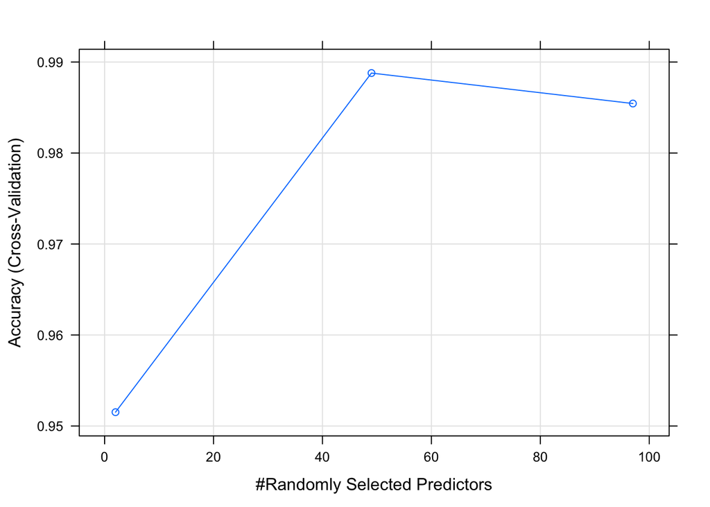

```r
plot(m2)
```

Let’s compare w/ accuracy on held-out data:

```r
m2P <- predict(m2, testingPP)
confusionMatrix(m2P, testingPP$classe)
```

```
## Confusion Matrix and Statistics
##
##           Reference
## Prediction    A    B    C    D    E
##          A 1674   11    0    0    0
##          B    0 1127    3    1    1
##          C    0    1 1019    6    2
##          D    0    0    4  956    3
##          E    0    0    0    1 1076
##
## Overall Statistics
##
##                Accuracy : 0.9944
##                  95% CI : (0.9921, 0.9961)
##     No Information Rate : 0.2845
##     P-Value [Acc > NIR] : < 2.2e-16
##
##                   Kappa : 0.9929
##  Mcnemar's Test P-Value : NA
##
## Statistics by Class:
##
##                      Class: A Class: B Class: C Class: D Class: E
## Sensitivity            1.0000   0.9895   0.9932   0.9917   0.9945
## Specificity            0.9974   0.9989   0.9981   0.9986   0.9998
## Pos Pred Value         0.9935   0.9956   0.9912   0.9927   0.9991
## Neg Pred Value         1.0000   0.9975   0.9986   0.9984   0.9988
## Prevalence             0.2845   0.1935   0.1743   0.1638   0.1839
## Detection Rate         0.2845   0.1915   0.1732   0.1624   0.1828
## Detection Prevalence   0.2863   0.1924   0.1747   0.1636   0.1830
## Balanced Accuracy      0.9987   0.9942   0.9957   0.9951   0.9971
```

## Conclusion

Accuracy on held-out data is inline w/ cross-validation accuracy, which is a good sign this model is generalizing. Accuracy is also well behaved across classes, which is important since this is a multiclass problem.

## Final predictions

```r
quizDS <- read.csv(gzfile("./pml-testing.csv.gz"))
quizDS <- as.data.frame(lapply(quizDS, as.numeric))
quizPP <- predict(ppM, quizDS)
quizPreds <- predict(m2, quizPP)
data.frame(preds=quizPreds, problem_id=quizPP$problem_id)
```

```
##    preds problem_id
## 1      B          1
## 2      A          2
## 3      B          3
## 4      A          4
## 5      A          5
## 6      E          6
## 7      D          7
## 8      B          8
## 9      A          9
## 10     A         10
## 11     B         11
## 12     C         12
## 13     B         13
## 14     A         14
## 15     E         15
## 16     E         16
## 17     A         17
## 18     B         18
## 19     B         19
## 20     B         20
```